# Quick high quality maps with R

Jan-Philipp Kolb

16 6 2021

# Preliminaries

- Usually I have big differences in knowledge and abilities of the participants - please tell, if it is too fast or slow.
- We have lots of hands-on coding [**exercises**](http://web.math.ku.dk/~helle/R-intro/exercises.pdf) - later you can only learn on your own
- We have many [**examples**](https://www.showmeshiny.com/) - try them
- If there are questions - always ask
- R is more fun together - strong proponent of collaborative work!

# What is the purpose of this course

- Quick
- Easy to use

# Getting help on packages

```r
# provides details regarding contents of a package
help(package = "osmplotr")
# list vignettes available for a specific package
vignette(package="osmplotr")
# view specific vignette
vignette("data-maps")
```

# The `World` dataset

### Natural Earth

- Dataset contains information from [**Natural Earth**](http://www.naturalearthdata.com/)

```r
data(World)
```

[figure not shown]

# The `qtm` command from the `tmap` package

### Fast thematic map

- With the command [**qtm**](https://cran.r-project.org/web/packages/tmap/vignettes/tmap-nutshell.html) you can create a fast thematic map
- Example from the [**Vignette**](https://cran.r-project.org/web/packages/tmap/vignettes/tmap-nutshell.html) for the `tmap` package

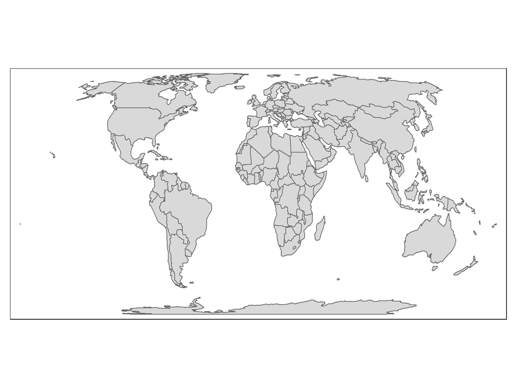

```r
library(tmap)
data(World)
qtm(World)
```

# To get more color in the map

### economic development status

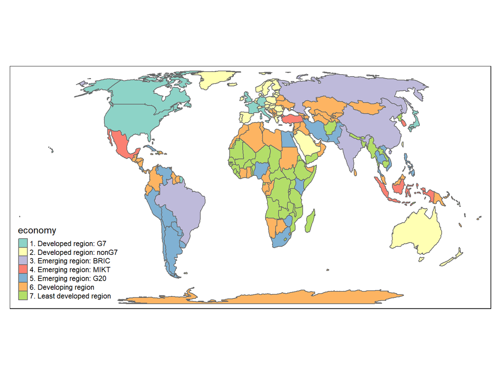

```r
qtm(World, fill="economy")
```

# A map with text

### Population

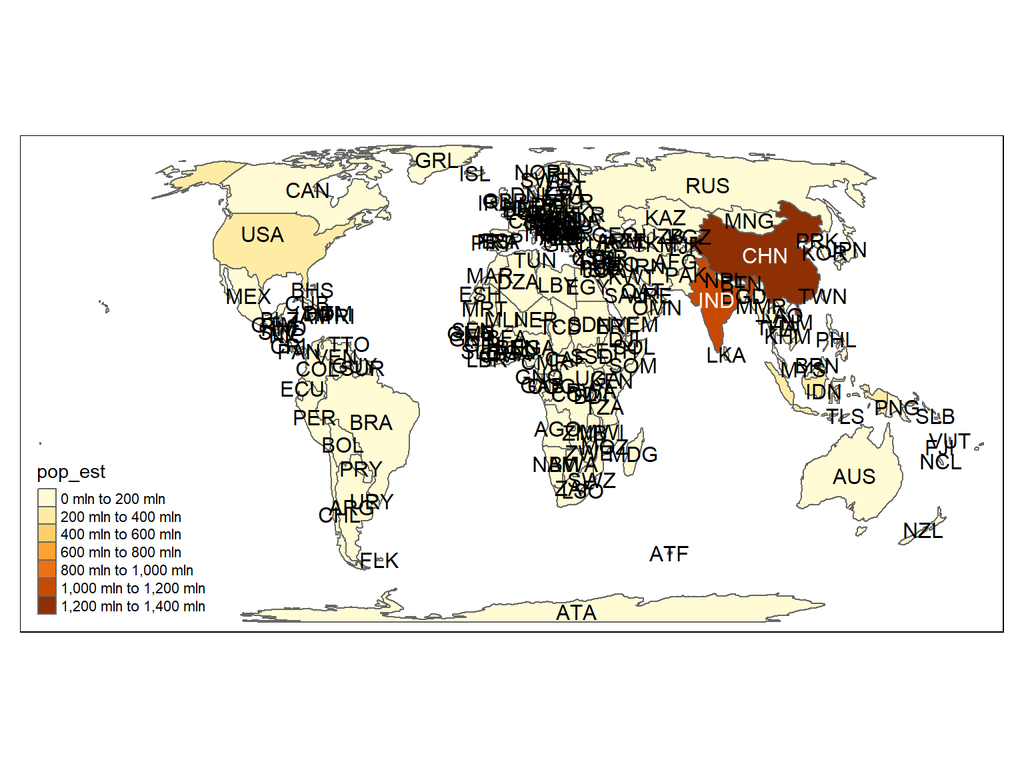

```r
qtm(World, fill="pop_est", text="iso_a3")
```

# This Scheme is better:

### [**GDP**](https://en.wikipedia.org/wiki/Population_density)

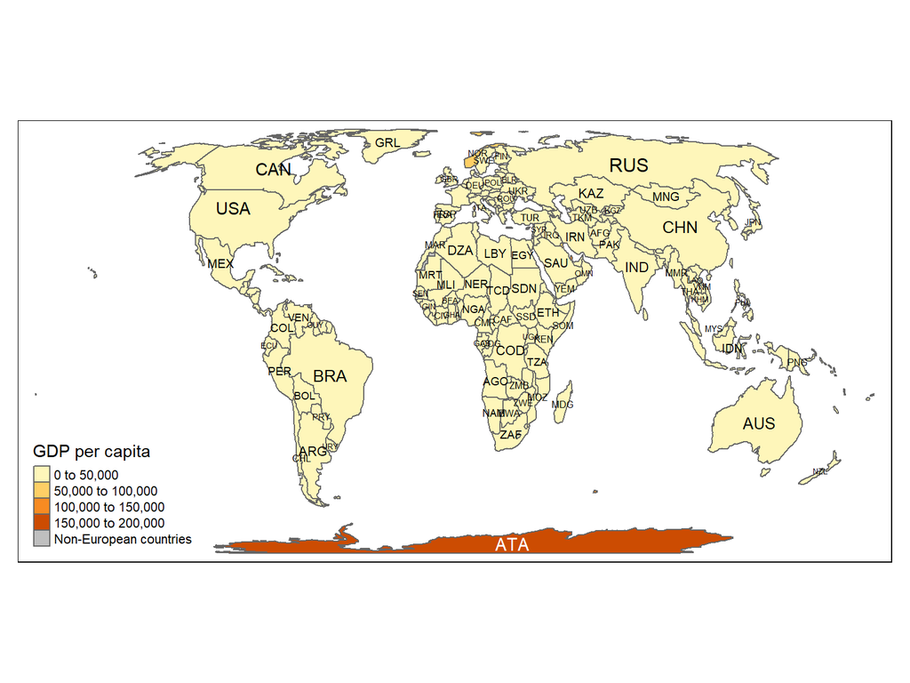

```r
qtm(World, fill="gdp_cap_est", text="iso_a3",
    text.size="AREA", root=5, fill.title="GDP per capita",
    fill.textNA="Non-European countries", theme="Europe")
```

# Topics of the World dataset

### Available variables in the data set

- [**ISO classification**](http://userpage.chemie.fu-berlin.de/diverse/doc/ISO_3166.html)
- country name
- Area, population, population density,
- [**Gross Domestic Product**](https://en.wikipedia.org/wiki/Gross_domestic_product)
- Gross domestic product [**at purchasing power parities**](https://en.wikipedia.org/wiki/List_of_countries_by_GDP_%28PPP%29_per_capita)
- Economy, income group

# The World Dataset - Variables and what’s behind

| iso_a3 | name | sovereignt | continent | area |
| --- | --- | --- | --- | --- |
| AFG | Afghanistan | Afghanistan | Asia | 652860.000 [km^2] |
| AGO | Angola | Angola | Africa | 1246700.000 [km^2] |
| ALB | Albania | Albania | Europe | 27400.000 [km^2] |
| ARE | United Arab Emirates | United Arab Emirates | Asia | 71252.172 [km^2] |
| ARG | Argentina | Argentina | South America | 2736690.000 [km^2] |
| ARM | Armenia | Armenia | Asia | 28470.000 [km^2] |
| ATA | Antarctica | Antarctica | Antarctica | 12259213.973 [km^2] |
| ATF | Fr. S. Antarctic Lands | France | Seven seas (open ocean) | 7257.455 [km^2] |

# The variable `continent`

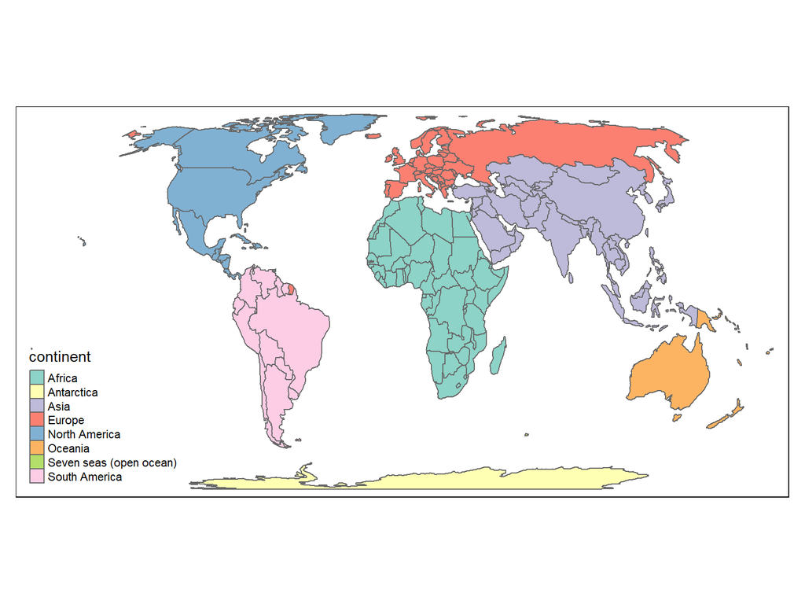

```r
qtm(World, fill="continent")
```

# The variable `area`

[figure not shown]

```r
qtm(World, fill="area") # Russia is huge
```

# Population

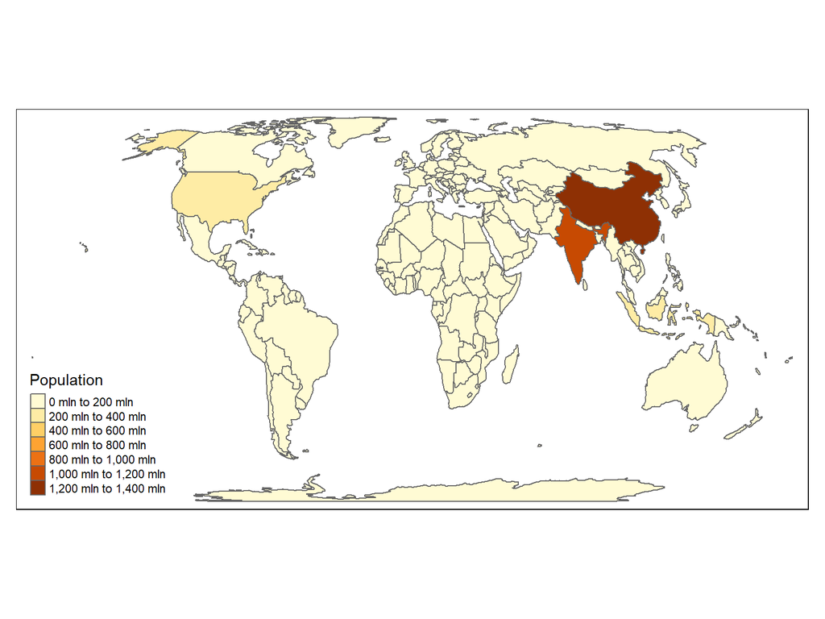

```r
qtm(World, fill="pop_est",fill.title="Population")
```

# Two maps

### Population and level of development

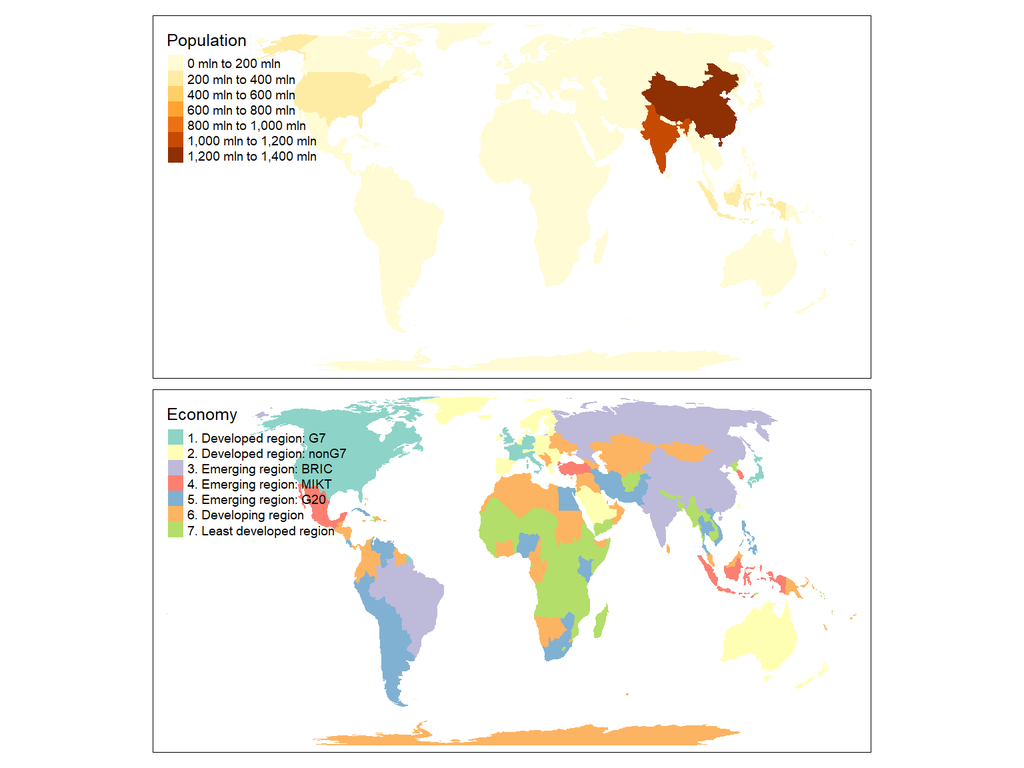

```r
tm_shape(World) + tm_fill(c("pop_est", "economy"),
        title=c("Population", "Economy"))
```